# Mjerenje uspješnosti mirovinskih fondova u RH

## PBZ

```
##
## Call:
## lm(formula = portfolio ~ referent, data = fondovi)
##
## Residuals:
##        Min         1Q     Median         3Q        Max
## -0.0129422 -0.0011146  0.0002055  0.0014055  0.0088171
##
## Coefficients:
##              Estimate Std. Error t value Pr(>|t|)
## (Intercept) 4.885e-05  1.653e-04   0.296    0.768
## referent    2.178e-01  2.634e-02   8.271 4.75e-15 ***
## ---
## Signif. codes:  0 '***' 0.001 '**' 0.01 '*' 0.05 '.' 0.1 ' ' 1
##
## Residual standard error: 0.002792 on 292 degrees of freedom
## Multiple R-squared:  0.1898, Adjusted R-squared:  0.187
## F-statistic: 68.41 on 1 and 292 DF,  p-value: 4.753e-15
```

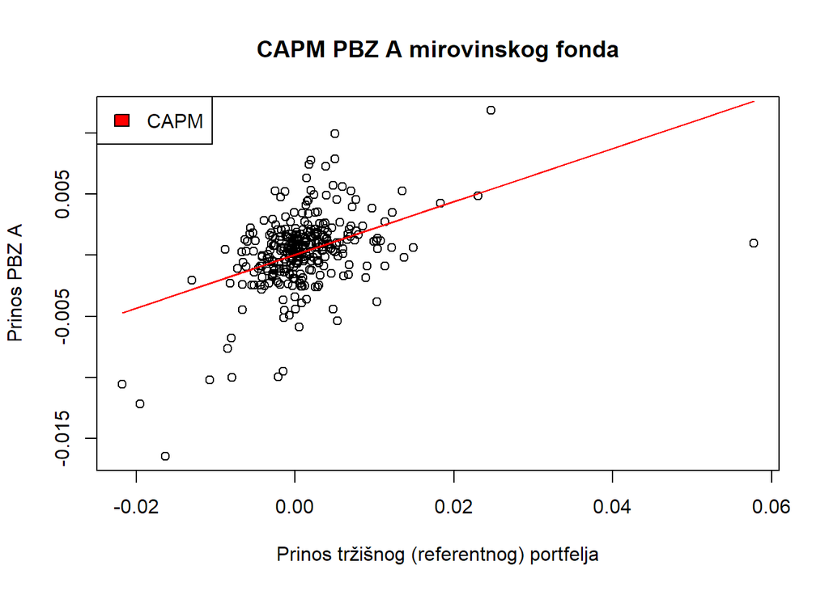

```
##
## Call:
## lm(formula = portfolio ~ referent + fondovi$crobis.povrat)
##
## Residuals:
##        Min         1Q     Median         3Q        Max
## -0.0126943 -0.0011388  0.0001982  0.0014051  0.0087257
##
## Coefficients:
##                         Estimate Std. Error t value Pr(>|t|)
## (Intercept)           -9.026e-06  1.654e-04  -0.055    0.957
## referent               2.241e-01  2.622e-02   8.550 7.12e-16 ***
## fondovi$crobis.povrat  2.462e-01  9.742e-02   2.528    0.012 *
## ---
## Signif. codes:  0 '***' 0.001 '**' 0.01 '*' 0.05 '.' 0.1 ' ' 1
##
## Residual standard error: 0.002767 on 291 degrees of freedom
## Multiple R-squared:  0.2072, Adjusted R-squared:  0.2018
## F-statistic: 38.03 on 2 and 291 DF,  p-value: 2.121e-15
```

```
##
## Call:
## lm(formula = portfolio ~ referent, data = fondovi)
##
## Residuals:
##        Min         1Q     Median         3Q        Max
## -0.0040919 -0.0004122 -0.0000714  0.0002683  0.0087643
##
## Coefficients:
##              Estimate Std. Error t value Pr(>|t|)
## (Intercept) 1.859e-04  5.705e-05   3.259  0.00125 **
## referent    5.388e-03  9.091e-03   0.593  0.55382
## ---
## Signif. codes:  0 '***' 0.001 '**' 0.01 '*' 0.05 '.' 0.1 ' ' 1
##
## Residual standard error: 0.0009637 on 292 degrees of freedom
## Multiple R-squared:  0.001202,   Adjusted R-squared:  -0.002219
## F-statistic: 0.3513 on 1 and 292 DF,  p-value: 0.5538
```

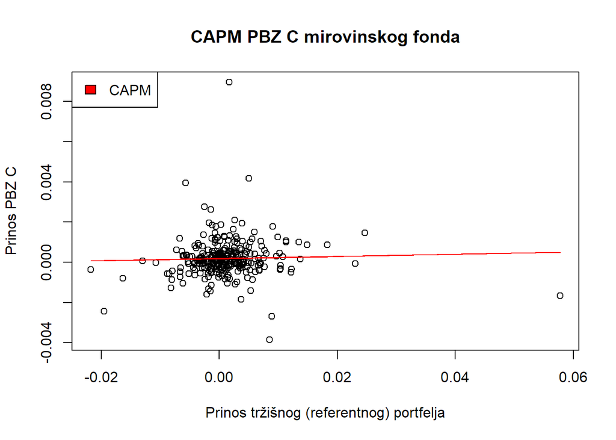

```
##
## Call:
## lm(formula = portfolio ~ referent + fondovi$crobis.povrat)
##
## Residuals:
##        Min         1Q     Median         3Q        Max
## -0.0037831 -0.0003966 -0.0000419  0.0002909  0.0089740
##
## Coefficients:
##                        Estimate Std. Error t value Pr(>|t|)
## (Intercept)           1.569e-04  5.638e-05   2.783 0.005740 **
## referent              8.549e-03  8.938e-03   0.957 0.339590
## fondovi$crobis.povrat 1.236e-01  3.321e-02   3.721 0.000238 ***
## ---
## Signif. codes:  0 '***' 0.001 '**' 0.01 '*' 0.05 '.' 0.1 ' ' 1
##
## Residual standard error: 0.0009432 on 291 degrees of freedom
## Multiple R-squared:  0.04657,    Adjusted R-squared:  0.04002
## F-statistic: 7.107 on 2 and 291 DF,  p-value: 0.000969
```

Modelom CAPM otvrđujemo značajnu vezu između PBZ A fonda i referentnog tržišnog portfelja. Nadalje, prošireni model koji u uzima i povrat na referentni portfelj državnih obveznica na prikazuje kako je povrat državnih obveznica manje značajan u odnosu na tržišni portfelj.

Suprotno kategoriji A fonda, PBZ C fond se modelom CAPM ne može signifikantno objasniti te je prema F-testu jednako dobar modelu bez neovisnih varijabli (p = 0.5538). Proširenim modelom utvrđujemo kako postoji značajan odnos između povrata portfelja i povrat referentnog portfelja državnih obveznica.

## Raiffeisen

```
##
## Call:
## lm(formula = portfolio ~ referent)
##
## Residuals:
##        Min         1Q     Median         3Q        Max
## -0.0145351 -0.0013140  0.0001843  0.0014610  0.0119337
##
## Coefficients:
##               Estimate Std. Error t value Pr(>|t|)
## (Intercept) -6.651e-05  1.643e-04  -0.405    0.686
## referent     2.285e-01  2.618e-02   8.727   <2e-16 ***
## ---
## Signif. codes:  0 '***' 0.001 '**' 0.01 '*' 0.05 '.' 0.1 ' ' 1
##
## Residual standard error: 0.002775 on 292 degrees of freedom
## Multiple R-squared:  0.2069, Adjusted R-squared:  0.2042
## F-statistic: 76.16 on 1 and 292 DF,  p-value: < 2.2e-16
```

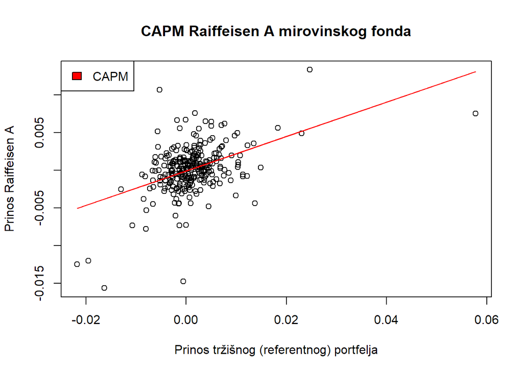

```
##
## Call:
## lm(formula = portfolio ~ referent + fondovi$crobis.povrat)
##
## Residuals:
##        Min         1Q     Median         3Q        Max
## -0.0146765 -0.0013253  0.0001572  0.0014879  0.0120274
##
## Coefficients:
##                         Estimate Std. Error t value Pr(>|t|)
## (Intercept)           -0.0001135  0.0001650  -0.688   0.4920
## referent               0.2335914  0.0261550   8.931   <2e-16 ***
## fondovi$crobis.povrat  0.2000084  0.0971891   2.058   0.0405 *
## ---
## Signif. codes:  0 '***' 0.001 '**' 0.01 '*' 0.05 '.' 0.1 ' ' 1
##
## Residual standard error: 0.00276 on 291 degrees of freedom
## Multiple R-squared:  0.2182, Adjusted R-squared:  0.2129
## F-statistic: 40.62 on 2 and 291 DF,  p-value: 2.766e-16
```

```
##
## Call:
## lm(formula = portfolio ~ referent)
##
## Residuals:
##        Min         1Q     Median         3Q        Max
## -0.0064867 -0.0003943 -0.0000201  0.0003266  0.0073364
##
## Coefficients:
##              Estimate Std. Error t value Pr(>|t|)
## (Intercept) 1.345e-04  5.908e-05   2.276   0.0235 *
## referent    2.501e-03  9.414e-03   0.266   0.7907
## ---
## Signif. codes:  0 '***' 0.001 '**' 0.01 '*' 0.05 '.' 0.1 ' ' 1
##
## Residual standard error: 0.000998 on 292 degrees of freedom
## Multiple R-squared:  0.0002416,  Adjusted R-squared:  -0.003182
## F-statistic: 0.07057 on 1 and 292 DF,  p-value: 0.7907
```

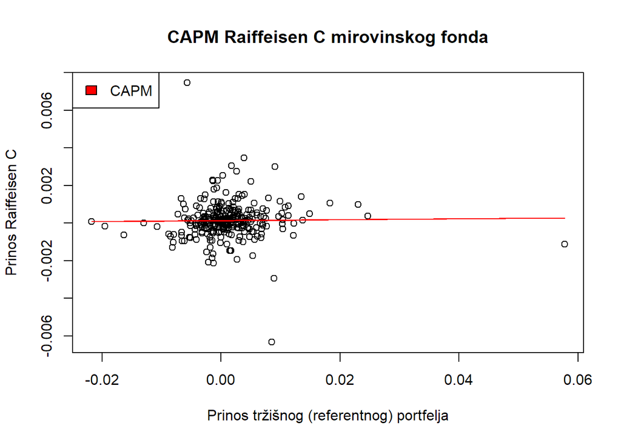

```
##
## Call:
## lm(formula = portfolio ~ referent + fondovi$crobis.povrat)
##
## Residuals:
##        Min         1Q     Median         3Q        Max
## -0.0061206 -0.0003983 -0.0000231  0.0003681  0.0064403
##
## Coefficients:
##                        Estimate Std. Error t value Pr(>|t|)
## (Intercept)           1.001e-04  5.795e-05   1.727   0.0853 .
## referent              6.248e-03  9.187e-03   0.680   0.4970
## fondovi$crobis.povrat 1.465e-01  3.414e-02   4.292 2.42e-05 ***
## ---
## Signif. codes:  0 '***' 0.001 '**' 0.01 '*' 0.05 '.' 0.1 ' ' 1
##
## Residual standard error: 0.0009695 on 291 degrees of freedom
## Multiple R-squared:  0.05975,    Adjusted R-squared:  0.05329
## F-statistic: 9.247 on 2 and 291 DF,  p-value: 0.0001278
```

Prema modelu povrata CAPM Raiffeisen A fonda, utvrđujemo značajnu vezu s povratom referentnog tržišnog portfelja. F-statistikom utvrđujemo kako je model signifikantan u odnosu na model bez neovisnih varijabli. Prošireni model koji dodatno obuhvaća povrat na referentni portfelj državnih obveznica nam prikazuje kako je upravo taj povrat državnih obveznica manje značajan u odnosu na tržišni portfelj, iako i dalje značajan uz razinu signifikantnosti od 5%. Povećanjem $R^2$ utvrđujemo kako je ovaj prošireni model bolje prilagođen na dostupne podatke. Ovakvu razliku u signifikantnosti između regresora proširenog modela možemo tumačiti prema tome što rizičniji fond koristi rizičnije tržište dionica više kako bi postigao veće povrate.

U odnosu na fond kategorije A, Raiffeisen C se modelom CAPM ne može signifikantno objasniti te je jednako dobar modelu bez neovisnih varijabli prema F-testu (p = 0.7907). Međutim, proširenim modelom utvrđujemo kako postoji značajan odnos između povrata portfelja i povrata referentnog portfelja državnih obveznica. Ovakve rezultate možemo tumačiti time da se fond kategorije C, upravo u nastojanju bezrizičnosti, u najvećoj mjeri ravna prema referentnom obvezničkom portfelju, to jeste ulaganjem u državne obveznice kao manje rizičnom instrumentu ulaganja.

# Zaključak

Odabiremo PBZ C jer je njegova vrijednost koeficijenta $\alpha$ veći od ostalih koeficijenata koje smo izračunali.